# Homework 09

## Question 1

### a)

Download the latest US State-level COVID-19 dataset from the New York Times data portal from https://raw.githubusercontent.com/nytimes/covid-19-data/master/us-states.csv. You should be able to use `read_csv()` to immediately download this data as long as you are connected to the internet.

```r
nyt_data <- read_csv("https://raw.githubusercontent.com/nytimes/covid-19-data/master/us-states.csv")
```

### b)

Calculate and report in a sentence the mean number of new COVID deaths reported in New York from January 1st, 2022 to now. In order to do this:

1. First filter the COVID State dataset to contain only information from New York
2. Next, arrange the observations according to date.
3. Create a new variable called `new_deaths` by using `mutate(new_deaths = deaths - lag(deaths))`. The `lag()` function will look backward one observation to obtain cases from the previous day.
4. Filter the data frame to only include dates from 01/01/22 onwards. This column should be in date format, so using >= logic will work.

```r
ny_nyt_df <- nyt_data %>%
  filter(state == "New York") %>%
  arrange(date) %>%
  mutate(new_deaths = deaths - lag(deaths)) %>%
  filter(date >= "2022-01-01")
```

### c)

Compute and report the 95% confidence interval of the mean number of new deaths reported (using the standard formula for SE) in New York over from 01/01/22 onward.

```r
mean_df <- ny_nyt_df %>%
  group_by(state) %>%
  summarize(mean_new_deaths = mean(new_deaths),
            total_new_deaths = n(),
            se = sd(new_deaths)/sqrt(total_new_deaths),
            lower_ci = mean_new_deaths - 1.96*se,
            upper_ci = mean_new_deaths + 1.96*se)
```

*Note: for some reason inline r code wouldn’t recognize my variables here*

### d)

Now compute and report the the 95% confidence interval of the mean number of new deaths reported (using bootstrapping to obtain the empirical 95% confidence interval) in New York over from 01/01/22 onward. Use 2000 bootstrap replicates to construct your confidence interval, and *include a histogram of the distribution of bootstrapped mean reported deaths.*

```r
#getting the mean

get_mean <- function(df){
  deaths <- df %>%
    pull(new_deaths)
  mean_new_deaths <- mean(deaths)
  return(mean_new_deaths)
}

point_estimate <- get_mean(ny_nyt_df)
point_estimate
```

```
## [1] 89.76344
```

```r
#bootstrapped sample
boot_sample <- function(df) {
  boot_df <- df %>%
    slice_sample(prop = 1, replace = TRUE)
  return(boot_df)
}

#obs data vs bootstrap data
ny_nyt_df
```

```
## # A tibble: 93 × 6
##    date       state    fips    cases deaths new_deaths
##    <date>     <chr>    <chr>   <dbl>  <dbl>      <dbl>
##  1 2022-01-01 New York 36    3555047  59072         79
##  2 2022-01-02 New York 36    3617589  59152         80
##  3 2022-01-03 New York 36    3678042  59240         88
##  4 2022-01-04 New York 36    3729331  59339         99
##  5 2022-01-05 New York 36    3804480  59485        146
##  6 2022-01-06 New York 36    3884858  59631        146
##  7 2022-01-07 New York 36    3966952  59827        196
##  8 2022-01-08 New York 36    4057084  59913         86
##  9 2022-01-09 New York 36    4136861  60083        170
## 10 2022-01-10 New York 36    4194745  60162         79
## # … with 83 more rows
```

```r
boot_sample(ny_nyt_df)
```

```
## # A tibble: 93 × 6
##    date       state    fips    cases deaths new_deaths
##    <date>     <chr>    <chr>   <dbl>  <dbl>      <dbl>
##  1 2022-02-12 New York 36    4864803  65785          0
##  2 2022-01-03 New York 36    3678042  59240         88
##  3 2022-02-27 New York 36    4907229  66726         45
##  4 2022-01-25 New York 36    4714703  63264        304
##  5 2022-01-08 New York 36    4057084  59913         86
##  6 2022-02-13 New York 36    4870144  65912        127
##  7 2022-03-26 New York 36    4961905  67264         10
##  8 2022-03-26 New York 36    4961905  67264         10
##  9 2022-03-31 New York 36    4978875  67313          7
## 10 2022-02-26 New York 36    4904574  66681         23
## # … with 83 more rows
```

```r
#combine functions
bootstrap_mean_function <- function(df){
  boot_df <- boot_sample(df)
  boot_stat <- get_mean(boot_df)
  return(boot_stat)
}

#run a bunch of times
bootstrap_mean_function(ny_nyt_df)
```

```
## [1] 85.91398
```

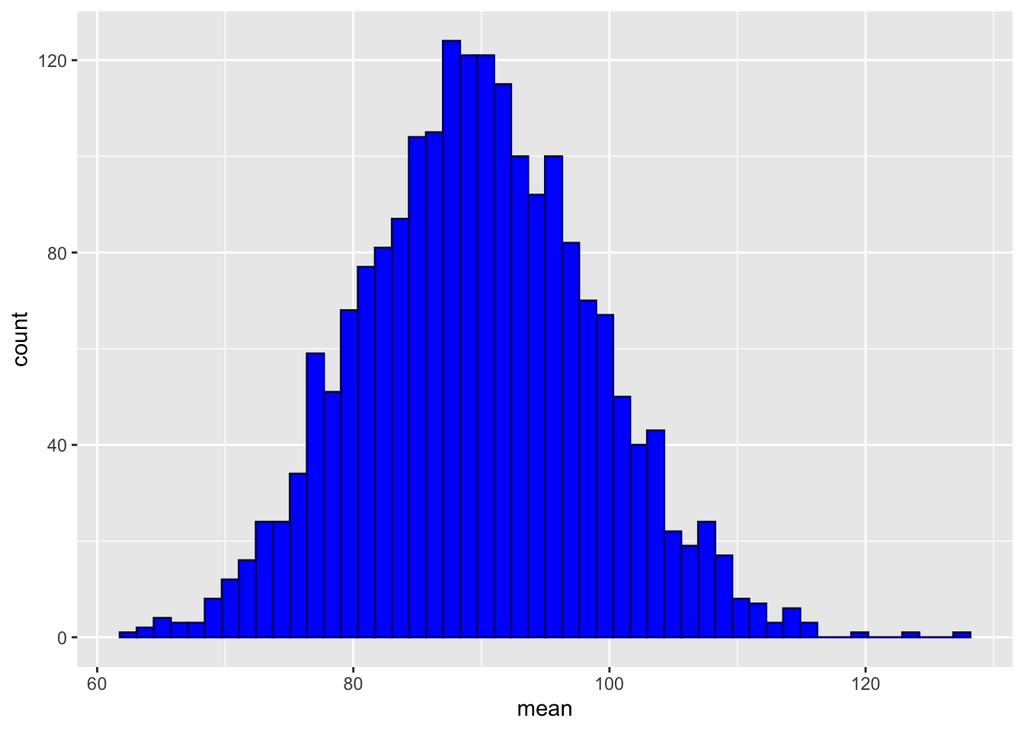

```r
bootstrap_running <- map_dbl(1:2000, function(x) bootstrap_mean_function(ny_nyt_df))
res_tibble <- tibble(run = 1:2000, mean = bootstrap_running)

#plotting
ggplot(data = res_tibble) +
  geom_histogram(aes(x = mean), bins = 50, fill = "blue", color = "navy")
```

```r
#CI
bootstrap_LL <- quantile(bootstrap_running, 0.025, na.rm = TRUE)
bootstrap_UL <- quantile(bootstrap_running, 0.975, na.rm = TRUE)

point_estimate
```

```
## [1] 89.76344
```

```r
bootstrap_LL
```

```
##     2.5%
## 72.47231
```

```r
bootstrap_UL
```

```
##    97.5%
## 108.0234
```

### e)

Compare the confidence intervals in parts (c) and (d). Are they the same? Different? If they are different, which confidence interval is wider, and by how much?

### f)

Select five states of your choosing and create a line graph showing newly reported COVID-19 daily deaths from 01/01/21 onward, with states differentiated by color. Make at least *(3)* improvements to a basic ggplot (think about labeling, custom colors, themes, etc)

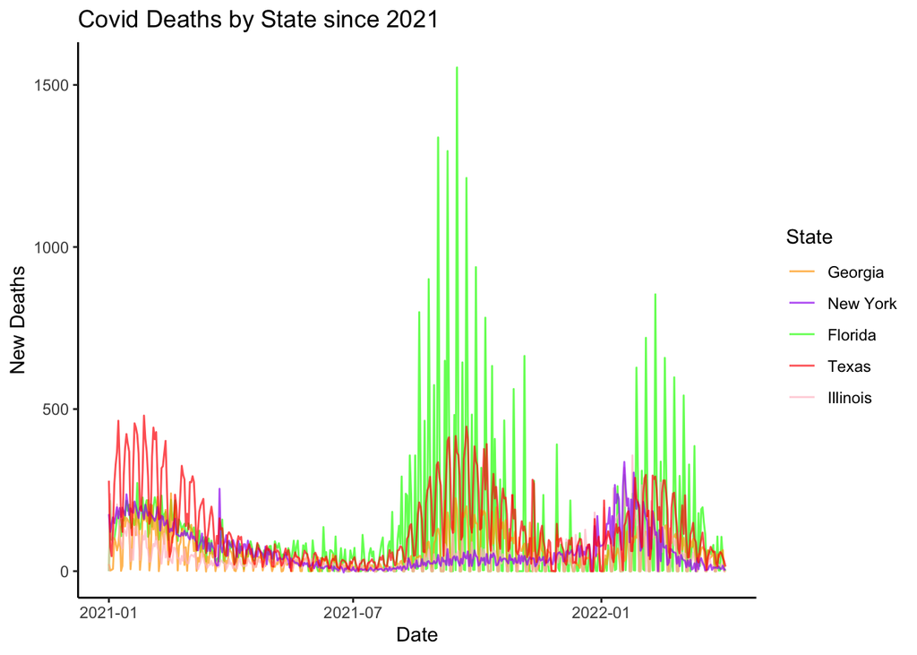

```r
five_states <- nyt_data %>%
  filter(state == "Georgia" | state == "New York" | state == "Florida" | state == "Texas" | state == "Illinois") %>%
  arrange(date) %>%
  group_by(state) %>%
  mutate(new_deaths = deaths - lag(deaths)) %>%
  filter(date >= "2021-01-01")

ggplot(data = five_states) +
  geom_line(aes(x = date, y = new_deaths, group = state, color = state), alpha = 0.7) +
  labs(title = "Covid Deaths by State since 2021", x = "Date", y = "New Deaths", color = "State") +
  scale_color_manual(values = c("Georgia" = "orange", "New York" = "purple", "Florida" = "green", "Texas" = "red", "Illinois" = "pink")) +
                       theme_classic()
```

## Question 2

You have received two raw datasets containing the exposure status and demographics for a small pilot study. The data is currently a bit messy, so your first goal is to clean it and produce a small table 1 describing the demographics between two groups.

### a)

Load the `pilot_exposure.csv` and `pilot_demo.csv` files into your environment. Figure out how to join them together so only participants with exposure information are included in the final file.

```r
pilot_exposure <- read_csv("data/pilot_exposure.csv")
pilot_demo <- read_csv("data/pilot_demo.csv")

#pilot_exposure requires some reformatting of the ID variable

pilot_exposure_edited <- pilot_exposure %>%
  mutate(id_number = str_remove(id_number, "STUDY-114:ID:"),
         id_number = as.numeric(id_number)
         )

pilot_combined <- left_join(pilot_exposure_edited, pilot_demo, by = "id_number") %>%
  rename(ethnicity = eth) %>%
  rename(marital_status = marital)
#checked that they all have exposure statuses
```

### b)

You have been asked to clean up the demographic data and code variables into the following categories:

**Gender** “Male” and “Female” (Current coding has 0 = Male and 1 = Female)

**Ethnicity** “Hispanic” and “Non-Hispanic”

**Race** “White”, “Black”, “Unknown”

**Marital Status** “Single/Separated/Divorced” and “Married”

Use string manipulation functions to create these variables and categories.

```r
pilot_combined_edited <- pilot_combined %>%
  mutate(gender = case_when(str_detect(gender, "0") ~ "Male",
                                  str_detect(gender, "1") ~ "Female")) %>%
  mutate(ethnicity = case_when(str_detect(ethnicity, "N-Hispanic") ~ "Non-Hispanic",
                                     str_detect(ethnicity, "isp") ~ "Hispanic")) %>%
  mutate(race = case_when(str_detect(race, "Unknown|unk|not known") ~ "Unknown",
                          str_detect(race, "WHITE|white|White|wh") ~ "White",
                          str_detect(race, "BLACK|black|Black") ~ "Black")) %>%
  mutate(marital_status = case_when(str_detect(marital_status, "single|Sin|DEFINITELY S|Separated|divorced|Div") ~ "Single/Separated/Divorced",
                                    str_detect(marital_status, "marred|Maried")~"Married"))
```

### c)

Now that the variables have been cleaned, create a descriptive table of the entire sample using `tbl_summary()`.

Make sure:

1. You include your cleaned gender, race, ethnicity, and marital status variables as well as age and education in years in your table.
2. Categorical variables are summarized using n(%) and continuous variables are summarized using mean(sd).
3. Each variable is labeled, not left with just a raw variable name.

```r
pilot_combined_edited %>%
  select(edu_yrs, age, ethnicity, gender, race, marital_status) %>%
  tbl_summary(statistic = list(all_continuous() ~ "{mean} ({sd}); ({min}, {max})",
                               all_categorical() ~ "{n} ({p}%)"),
              label = list(gender ~ "Gender", age ~ "Age", ethnicity ~ "Ethnicity", race ~ "Race", marital_status ~ "Marital Status", edu_yrs ~ "Years of Education")) %>%
  bold_labels()
```

| **Characteristic** | **N = 18**<sup>1</sup> |
| --- | --- |
| Years of Education |  |
| 10 | 2 (11%) |
| 11 | 1 (5.6%) |
| 12 | 4 (22%) |
| 13 | 1 (5.6%) |
| 14 | 5 (28%) |
| 16 | 3 (17%) |
| 20 | 2 (11%) |
| Age | 40 (11); (23, 56) |
| Ethnicity |  |
| Hispanic | 15 (83%) |
| Non-Hispanic | 3 (17%) |
| Gender |  |
| Female | 4 (22%) |
| Male | 14 (78%) |
| Race |  |
| Black | 5 (28%) |
| Unknown | 7 (39%) |
| White | 6 (33%) |
| Marital Status |  |
| Married | 6 (33%) |
| Single/Separated/Divorced | 12 (67%) |

<sup>1</sup> n (%); Mean (SD); (Range)

### d)

Now create a table with the same variables split by exposure group status. Include a column that shows the p-value for tests for differences between exposure groups for all variables. Make sure that the tests used for continuous variables are two-sample t-tests assuming equal variances.

```r
pilot_combined_edited %>%
  select(gender, ethnicity, race, marital_status, age, edu_yrs, exposure_status) %>%
  mutate(age = as.numeric(age)) %>%
  mutate(edu_yrs = as.numeric(edu_yrs)) %>%
  tbl_summary(by = exposure_status,
              statistic = list(all_continuous() ~ "{mean} ({sd})"),
              type = list(edu_yrs = "continuous"),
              label = list(exposure_status = "Exposure Status",
                          gender ~ "Gender",
                           age ~ "Age",
                           ethnicity ~ "Ethnicity",
                           race ~ "Race",
                           marital_status ~ "Marital Status",
                           edu_yrs ~ "Years of Education")) %>%
  bold_labels() %>%
  add_overall() %>%  # add an overall column
  add_p(test = all_continuous() ~ "t.test", # adding a p-value
        test.args = all_tests("t.test") ~ list(var.equal = TRUE)) # change options for a test that generates the pvalue
```

| **Characteristic** | **Overall**, N = 18<sup>1</sup> | **Exposed**, N = 3<sup>1</sup> | **Unexposed**, N = 15<sup>1</sup> | **p-value**<sup>2</sup> |
| --- | --- | --- | --- | --- |
| Gender |  |  |  | >0.9 |
| Female | 4 (22%) | 0 (0%) | 4 (27%) |  |
| Male | 14 (78%) | 3 (100%) | 11 (73%) |  |
| Ethnicity |  |  |  | 0.4 |
| Hispanic | 15 (83%) | 2 (67%) | 13 (87%) |  |
| Non-Hispanic | 3 (17%) | 1 (33%) | 2 (13%) |  |
| Race |  |  |  | 0.6 |
| Black | 5 (28%) | 0 (0%) | 5 (33%) |  |
| Unknown | 7 (39%) | 1 (33%) | 6 (40%) |  |
| White | 6 (33%) | 2 (67%) | 4 (27%) |  |
| Marital Status |  |  |  | 0.2 |
| Married | 6 (33%) | 2 (67%) | 4 (27%) |  |
| Single/Separated/Divorced | 12 (67%) | 1 (33%) | 11 (73%) |  |
| Age | 40 (11) | 46 (14) | 39 (11) | 0.4 |
| Years of Education | 13.9 (2.9) | 15.3 (4.2) | 13.6 (2.7) | 0.4 |

<sup>1</sup> n (%); Mean (SD)  
<sup>2</sup> Fisher's exact test; Two Sample t-test

## Question 3

Last week you explored associations between skeletal/girth measures and obesity status. For this problem, we’ll be returning to those models using the same `body_measures.csv` dataset.

### a)

**If you did not complete Q3 in HW08:** you must fit logistic regression models to explore the relationship between obesity status and three skeletal/girth measurements of your choice. This means you need to calculate BMI and create the 0/1 obesity outcome based on a BMI >= 30. You should result in 3 models, each one exploring the relationship between a measurement and obesity status. Your models can include adjustment for other variables if you wish.

**If you completed Q3 in HW08:** you can cut/paste your code from that assignment to set up the data and re-fit your three obesity status models.

```r
body_measures <- read_csv("data/body_measures.csv")

clean_body <- body_measures %>%
  mutate(bmi = weight / ((height/100)^2)) %>%
  mutate(obese = if_else(bmi >= 30, 1, 0))

#chest girth vs obesity status
chest_obese_model <- glm(obese ~ chest_girth, family = "binomial", data = clean_body)

tidy_chest_obese_model <- tidy(chest_obese_model, exponentiate = TRUE, conf.int = TRUE)
kable(tidy_chest_obese_model)
```

| term | estimate | std.error | statistic | p.value | conf.low | conf.high |
| --- | --- | --- | --- | --- | --- | --- |
| (Intercept) | 0.000000 | 3.7621237 | -5.417978 | 1.0e-07 | 0.000000 | 0.0000011 |
| chest_girth | 1.185262 | 0.0354616 | 4.792898 | 1.6e-06 | 1.112219 | 1.2796837 |

```r
#waist girth vs obesity status
waist_obese_model <- glm(obese ~ waist_girth, family = "binomial", data = clean_body)
tidy_waist_obese_model <- tidy(waist_obese_model, exponentiate = TRUE, conf.int = TRUE)
kable(tidy_waist_obese_model)
```

| term | estimate | std.error | statistic | p.value | conf.low | conf.high |
| --- | --- | --- | --- | --- | --- | --- |
| (Intercept) | 0.000000 | 2.7941023 | -6.483549 | 0 | 0.000000 | 0.0000019 |
| waist_girth | 1.186751 | 0.0297187 | 5.761324 | 0 | 1.125323 | 1.2661117 |

```r
#hip girth vs obesity status
hip_obese_model <- glm(obese ~ hip_girth, family = "binomial", data = clean_body)
tidy_hip_obese_model <- tidy(hip_obese_model, exponentiate = TRUE, conf.int = TRUE)
kable(tidy_hip_obese_model)
```

| term | estimate | std.error | statistic | p.value | conf.low | conf.high |
| --- | --- | --- | --- | --- | --- | --- |
| (Intercept) | 0.000000 | 7.9105737 | -5.785224 | 0 | 0.000000 | 0.000000 |
| hip_girth | 1.505972 | 0.0734489 | 5.574472 | 0 | 1.327829 | 1.777898 |

### b)

One of your collaborators is very enthusiastic about reporting the BIC for each logistic regression model. This is a measure of overall model fit, with lower BIC indicating better fit. Use the `broom` package to access the BIC measure for each of your 3 logistic regression models and report them in a sentence using in-line coding.

```r
chest_bic <- glance(chest_obese_model)
waist_bic <- glance(waist_obese_model)
hip_bic <- glance(hip_obese_model)
```

### c)

Excited by the prospect of comparing models based on BIC, your colleague asks you to calculate the 95% CI for the BIC of each model. Unfortunately, you can’t find a formula anywhere online to do this – so you decide to bootstrap them using 1000 replicates. Show the simulated bootstrap distribution of BIC values for each model, and report the empirical 95% confidence interval for each model.

```r
#function for each measure
get_bic_chest <- function(df){
  model <- glm(obese ~ chest_girth, family = "binomial", data = df)
  BIC <- glance(model) %>%
    pull(BIC)
  return(BIC)
}

get_bic_waist <- function(df){
  model <- glm(obese ~ waist_girth, family = "binomial", data = df)
  BIC <- glance(model) %>%
    pull(BIC)
  return(BIC)
}

get_bic_hip <- function(df){
  model <- glm(obese ~ hip_girth, family = "binomial", data = df)
  BIC <- glance(model) %>%
    pull(BIC)
  return(BIC)
}

#test
#estimate_chest <- get_bic(clean_body, clean_body$chest_girth)
#estimate_chest
#same as before

get_bic_chest(clean_body)
```

```
## [1] 132.5018
```

```r
#bootstrap
create_bootstrap <- function(df){
  bootstrap_out <- df %>%
    slice_sample(prop = 1, replace = TRUE)
  return(bootstrap_out)
}


combo_chest <- function(df){
  bootstrap_out <- create_bootstrap(df)
  boot_stat <- get_bic_chest(bootstrap_out)
  return(boot_stat)
}

combo_chest(clean_body)
```

```
## [1] 89.01929
```

```r
combo_waist <- function(df){
  bootstrap_out <- create_bootstrap(df)
  boot_stat <- get_bic_waist(bootstrap_out)
  return(boot_stat)
}

combo_waist(clean_body)
```

```
## [1] 91.04977
```

```r
combo_hip <- function(df){
  bootstrap_out <- create_bootstrap(df)
  boot_stat <- get_bic_hip(bootstrap_out)
  return(boot_stat)
}

combo_hip(clean_body)
```

```
## [1] 83.52421
```

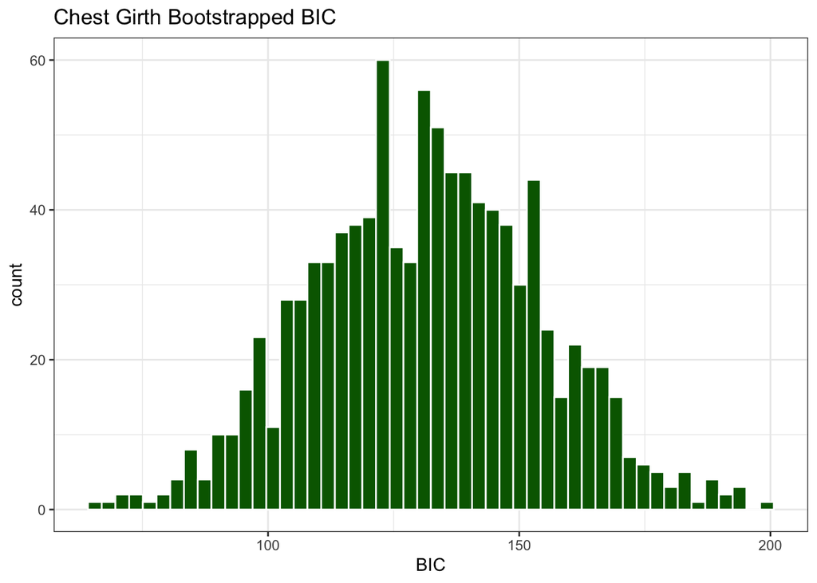

```r
#apply

##chest
bootstrap_chest <- map_dbl(1:1000, function(x) combo_chest(clean_body))

res_tibble_chest <- tibble(run = 1:1000, BIC = bootstrap_chest)

ggplot(data = res_tibble_chest) +
  geom_histogram(aes(x = BIC), bins = 50, fill = "darkgreen", color = "white") +
  theme_bw() +
  labs(title = "Chest Girth Bootstrapped BIC")
```

```r
lower_ci_chest <- quantile(bootstrap_chest, 0.0275)
upper_ci_chest <- quantile(bootstrap_chest, 0.975)

lower_ci_chest
```

```
##   2.75%
## 89.3955
```

```r
upper_ci_chest
```

```
##    97.5%
## 175.6307
```

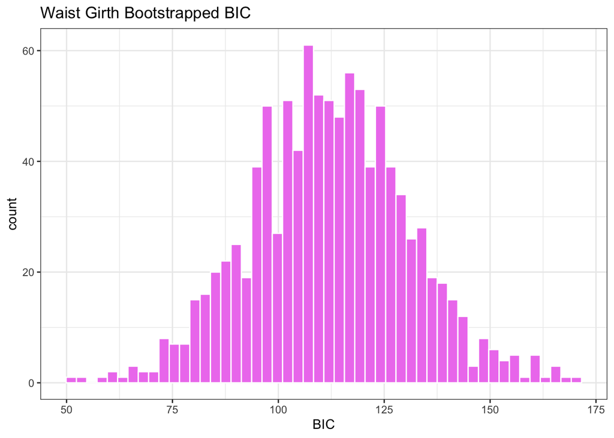

```r
##waist
bootstrap_waist <- map_dbl(1:1000, function(x) combo_waist(clean_body))

res_tibble_waist <- tibble(run = 1:1000, BIC = bootstrap_waist)

ggplot(data = res_tibble_waist) +
  geom_histogram(aes(x = BIC), bins = 50, fill = "violet", color = "white") +
  theme_bw() +
  labs(title = "Waist Girth Bootstrapped BIC")
```

```r
lower_ci_waist <- quantile(bootstrap_waist, 0.0275)
upper_ci_waist <- quantile(bootstrap_waist, 0.975)

lower_ci_waist
```

```
##    2.75%
## 76.55637
```

```r
upper_ci_waist
```

```
##    97.5%
## 149.7145
```

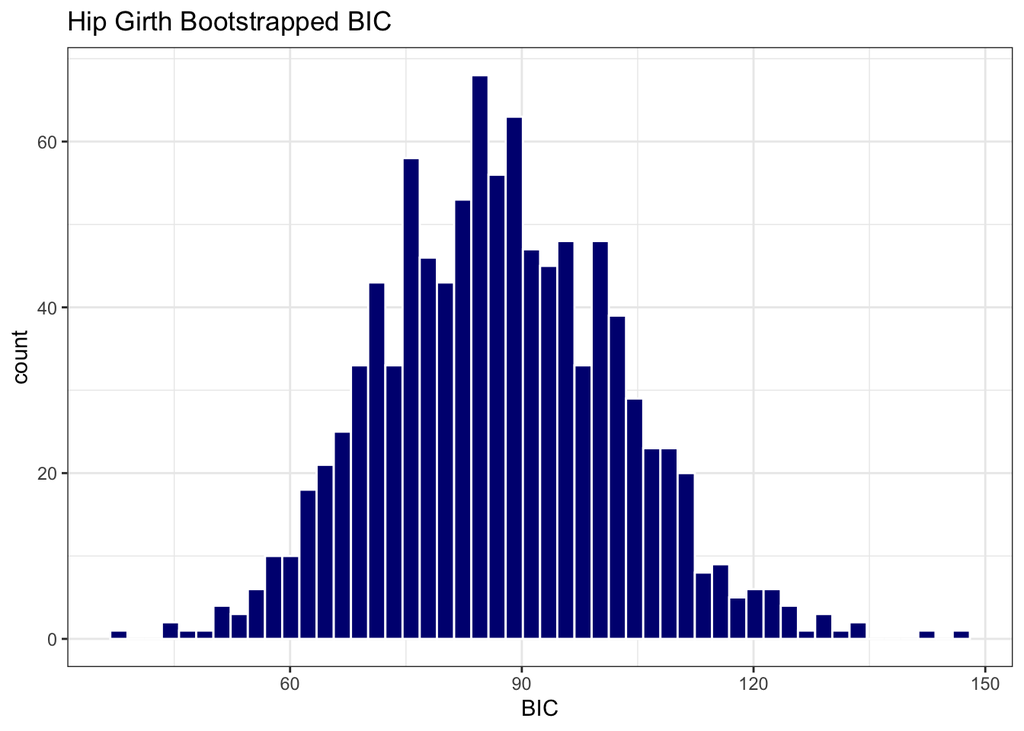

```r
#hip
bootstrap_hip <- map_dbl(1:1000, function(x) combo_hip(clean_body))

res_tibble_hip <- tibble(run = 1:1000, BIC = bootstrap_hip)

ggplot(data = res_tibble_hip) +
  geom_histogram(aes(x = BIC), bins = 50, fill = "navy", color = "white") +
  theme_bw() +
  labs(title = "Hip Girth Bootstrapped BIC")
```

```r
lower_ci_hip <- quantile(bootstrap_hip, 0.0275)
upper_ci_hip <- quantile(bootstrap_hip, 0.975)

lower_ci_hip
```

```
##    2.75%
## 58.98398
```

```r
upper_ci_hip
```

```
##    97.5%
## 119.0377
```

### d)

Next up, you’ve been asked to produce a combined plot of the OR’s and 95% CI for your measurements of interest and the BIC and bootstrapped 95% CI for each model in a “forest plot” type layout.

To do this: (1) Create one plot of the OR’s and 95% CI for your three measurements association with obesity. (2) Create a second plot of the BIC’s and 95% CI for your three models. (3) Combine the two plots using `patchwork`.

Make sure that: (1) Your two sub-plots have consistent themes. (2) Your axes are properly labeled, and the variables and models have clear descriptions (not raw variable names). (3) You indicate somehow that the 95% CI for BIC has been bootstrapped.

```r
tidy_chest <- tidy(chest_obese_model, exponentiate = TRUE, conf.int = TRUE) %>%
  mutate(outcome = "Obese") %>%
  filter(term == "chest_girth")
kable(tidy_chest)
```

| term | estimate | std.error | statistic | p.value | conf.low | conf.high | outcome |
| --- | --- | --- | --- | --- | --- | --- | --- |
| chest_girth | 1.185262 | 0.0354616 | 4.792898 | 1.6e-06 | 1.112219 | 1.279684 | Obese |

```r
tidy_waist <- tidy(waist_obese_model, exponentiate = TRUE, conf.int = TRUE) %>%
    mutate(outcome = "Obese") %>%
  filter(term == "waist_girth")
kable(tidy_waist)
```

| term | estimate | std.error | statistic | p.value | conf.low | conf.high | outcome |
| --- | --- | --- | --- | --- | --- | --- | --- |
| waist_girth | 1.186751 | 0.0297187 | 5.761324 | 0 | 1.125323 | 1.266112 | Obese |

```r
tidy_hip <- tidy(hip_obese_model, exponentiate = TRUE, conf.int = TRUE) %>%
    mutate(outcome = "Obese") %>%
  filter(term == "hip_girth")
kable(tidy_hip)
```

| term | estimate | std.error | statistic | p.value | conf.low | conf.high | outcome |
| --- | --- | --- | --- | --- | --- | --- | --- |
| hip_girth | 1.505972 | 0.0734489 | 5.574472 | 0 | 1.327829 | 1.777898 | Obese |

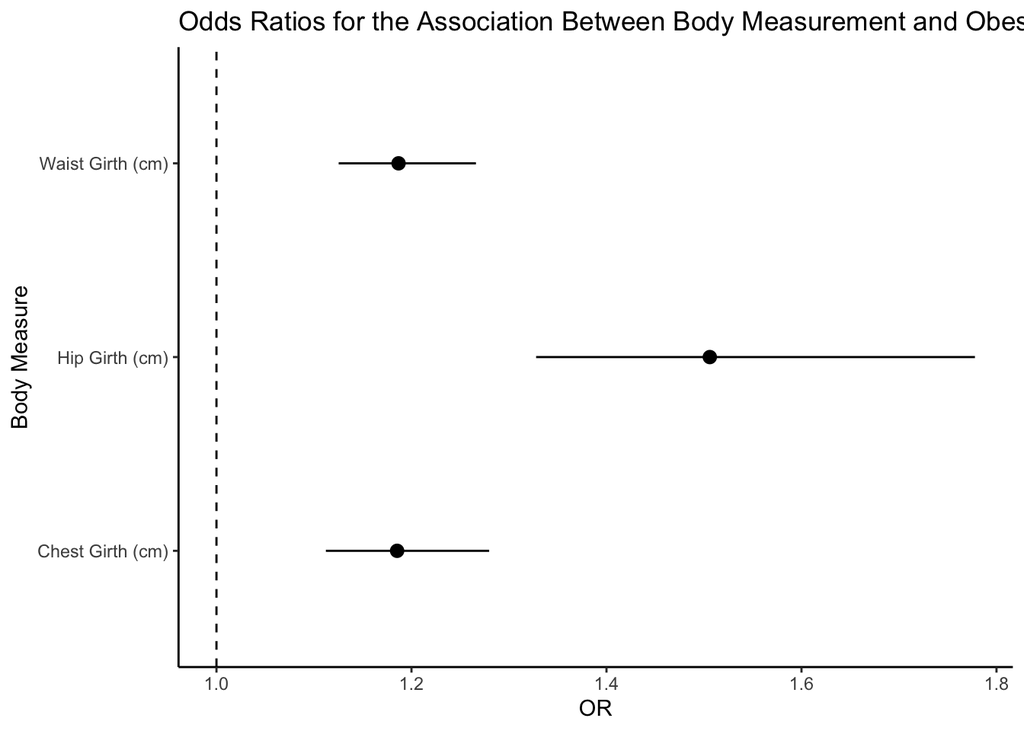

```r
or_df <- bind_rows(tidy_chest, tidy_waist, tidy_hip) %>%
  mutate(term_name = case_when(term == "chest_girth" ~ "Chest Girth (cm)",
                               term == "waist_girth" ~ "Waist Girth (cm)",
                               term == "hip_girth" ~ "Hip Girth (cm)"))

#first plot
or_plot <- ggplot(data = or_df) +
  geom_pointrange(aes(x = estimate, y = term_name, xmin = conf.low, xmax = conf.high)) +
  theme_classic() +
  geom_vline(aes(xintercept = 1), linetype = "dashed") +
  labs(x = "OR", y = "Body Measure", title = "Odds Ratios for the Association Between Body Measurement and Obesity")

or_plot
```

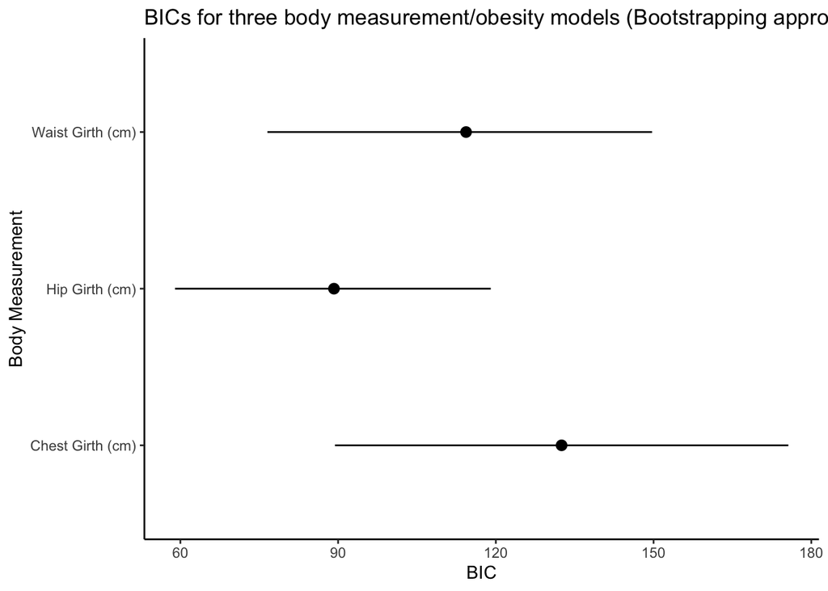

```r
#BIC plots

chest_bic <- chest_bic %>%
  mutate(lower_ci_BIC = lower_ci_chest,
         upper_ci_BIC = upper_ci_chest,
         term = "chest_girth")

waist_bic <- waist_bic %>%
  mutate(lower_ci_BIC = lower_ci_waist,
         upper_ci_BIC = upper_ci_waist,
         term = "waist_girth")

hip_bic <- hip_bic %>%
  mutate(lower_ci_BIC = lower_ci_hip,
         upper_ci_BIC = upper_ci_hip,
         term = "hip_girth")

all_bics <- bind_rows(chest_bic, waist_bic, hip_bic) %>%
  mutate(term_name = case_when(term == "chest_girth" ~ "Chest Girth (cm)",
                               term == "waist_girth" ~ "Waist Girth (cm)",
                               term == "hip_girth" ~ "Hip Girth (cm)"))

bic_plot <- ggplot(data = all_bics) +
  geom_pointrange(aes(x = BIC, y = term_name, xmin = lower_ci_BIC, xmax = upper_ci_BIC)) +
  theme_classic() +
  labs(x = "BIC", y = "Body Measurement", title = "BICs for three body measurement/obesity models (Bootstrapping approach)")

bic_plot
```

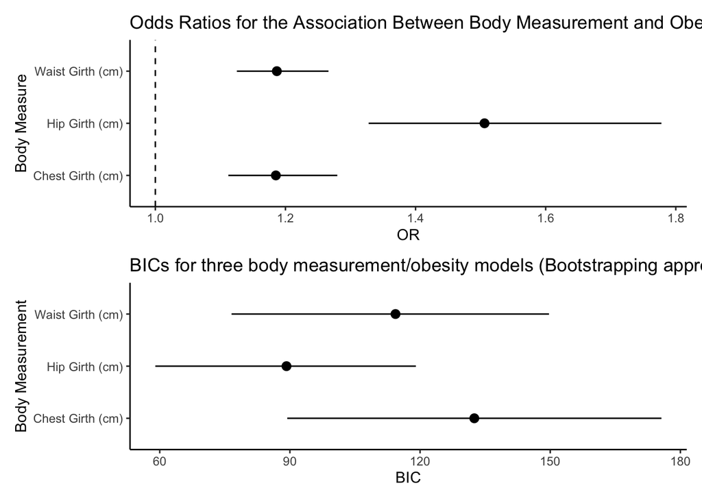

```r
or_plot / bic_plot
```

### e)

Based on the 95% CI’s in your graph in (e), would you say that the BIC for your three models differ? Why or why not?

**Based on the 95% confidence intervals in the graph in (e), I would say that the BIC for my three models slightly differ, but are not statistically significantly different. As we can see from the stacked plots, the confidence intervals overlap with each other.**